# R project ABA - Cécile Bonnet, Salomé Benyamin, Yingxue Guo, Nuno Gabriel Simoes Alves, Ilona Karaboulkov

# 1. Reformatting the dataset

## a) Reformat column names & column types

```r
names <- c("Id","State","District","Year","Rape","Kidnapping_Abduction","DowryDeaths","Assaults_Outrage","Insult","FamilyCruelty","Importation")
types = 'icciiiiiiii'
data1 <- read_csv("C:/Users/eyesg/OneDrive/Documentos/R/Advanced Business Analytics/Database/crimes_against_women_2001-2014.csv",col_names=names, skip=1, col_types=types)
#data1 <- read_csv("C:/Users/cecil/OneDrive/Documents/2-MSc BA/Data Visualization & Storytelling/Crimes.csv",col_names=names, skip=1, col_types=types)
head(data1)
```

```
## # A tibble: 6 x 11
##      Id State District  Year  Rape Kidnapping_Abdu~ DowryDeaths Assaults_Outrage
##   <int> <chr> <chr>    <int> <int>            <int>       <int>            <int>
## 1     0 ANDH~ ADILABAD  2001    50               30          16              149
## 2     1 ANDH~ ANANTAP~  2001    23               30           7              118
## 3     2 ANDH~ CHITTOOR  2001    27               34          14              112
## 4     3 ANDH~ CUDDAPAH  2001    20               20          17              126
## 5     4 ANDH~ EAST GO~  2001    23               26          12              109
## 6     5 ANDH~ GUNTAKA~  2001     0                0           0                1
## # ... with 3 more variables: Insult <int>, FamilyCruelty <int>,
## #   Importation <int>
```

## b) There are 28 states in India normally and 8 union territories

```r
unique(data1$State)
```

```
##  [1] "ANDHRA PRADESH"    "ARUNACHAL PRADESH" "ASSAM"
##  [4] "BIHAR"             "CHHATTISGARH"      "GOA"
##  [7] "GUJARAT"           "HARYANA"           "HIMACHAL PRADESH"
## [10] "JAMMU & KASHMIR"   "JHARKHAND"         "KARNATAKA"
## [13] "KERALA"            "MADHYA PRADESH"    "MAHARASHTRA"
## [16] "MANIPUR"           "MEGHALAYA"         "MIZORAM"
## [19] "NAGALAND"          "ODISHA"            "PUNJAB"
## [22] "RAJASTHAN"         "SIKKIM"            "TAMIL NADU"
## [25] "TRIPURA"           "UTTAR PRADESH"     "UTTARAKHAND"
## [28] "WEST BENGAL"       "A & N ISLANDS"     "CHANDIGARH"
## [31] "D & N HAVELI"      "DAMAN & DIU"       "DELHI"
## [34] "LAKSHADWEEP"       "PUDUCHERRY"        "Andhra Pradesh"
## [37] "Arunachal Pradesh" "Assam"             "Bihar"
## [40] "Chhattisgarh"      "Goa"               "Gujarat"
## [43] "Haryana"           "Himachal Pradesh"  "Jammu & Kashmir"
## [46] "Jharkhand"         "Karnataka"         "Kerala"
## [49] "Madhya Pradesh"    "Maharashtra"       "Manipur"
## [52] "Meghalaya"         "Mizoram"           "Nagaland"
## [55] "Odisha"            "Punjab"            "Rajasthan"
## [58] "Sikkim"            "Tamil Nadu"        "Tripura"
## [61] "Uttar Pradesh"     "Uttarakhand"       "West Bengal"
## [64] "A&N Islands"       "Chandigarh"        "D&N Haveli"
## [67] "Daman & Diu"       "Delhi UT"          "Lakshadweep"
## [70] "Puducherry"        "Telangana"         "A & N Islands"
```

```r
data1$State <- tolower(data1$State)
unique(data1$State)
```

```
##  [1] "andhra pradesh"    "arunachal pradesh" "assam"
##  [4] "bihar"             "chhattisgarh"      "goa"
##  [7] "gujarat"           "haryana"           "himachal pradesh"
## [10] "jammu & kashmir"   "jharkhand"         "karnataka"
## [13] "kerala"            "madhya pradesh"    "maharashtra"
## [16] "manipur"           "meghalaya"         "mizoram"
## [19] "nagaland"          "odisha"            "punjab"
## [22] "rajasthan"         "sikkim"            "tamil nadu"
## [25] "tripura"           "uttar pradesh"     "uttarakhand"
## [28] "west bengal"       "a & n islands"     "chandigarh"
## [31] "d & n haveli"      "daman & diu"       "delhi"
## [34] "lakshadweep"       "puducherry"        "a&n islands"
## [37] "d&n haveli"        "delhi ut"          "telangana"
```

```r
baddelhi <- c('delhi','delhi ut')
bad_d_and_n_haveli <- c("d&n haveli","d & n haveli")
bad_a_and_n_islands <- c("a&n islands","a & n islands")
data1 <- data1 %>%
  mutate(State=ifelse(State %in% baddelhi, 'delhi', State))
data1 <- data1 %>%
  mutate(State=ifelse(State %in% bad_d_and_n_haveli, 'd&n haveli', State))
data1 <- data1 %>%
  mutate(State=ifelse(State %in% bad_a_and_n_islands, 'a&n islands', State))
unique(data1$State)
```

```
##  [1] "andhra pradesh"    "arunachal pradesh" "assam"
##  [4] "bihar"             "chhattisgarh"      "goa"
##  [7] "gujarat"           "haryana"           "himachal pradesh"
## [10] "jammu & kashmir"   "jharkhand"         "karnataka"
## [13] "kerala"            "madhya pradesh"    "maharashtra"
## [16] "manipur"           "meghalaya"         "mizoram"
## [19] "nagaland"          "odisha"            "punjab"
## [22] "rajasthan"         "sikkim"            "tamil nadu"
## [25] "tripura"           "uttar pradesh"     "uttarakhand"
## [28] "west bengal"       "a&n islands"       "chandigarh"
## [31] "d&n haveli"        "daman & diu"       "delhi"
## [34] "lakshadweep"       "puducherry"        "telangana"
```

## c) Removing the district column

```r
data <- data1[,-(3),drop=FALSE]
head(data)
```

```
## # A tibble: 6 x 10
##      Id State    Year  Rape Kidnapping_Abdu~ DowryDeaths Assaults_Outrage Insult
##   <int> <chr>   <int> <int>            <int>       <int>            <int>  <int>
## 1     0 andhra~  2001    50               30          16              149     34
## 2     1 andhra~  2001    23               30           7              118     24
## 3     2 andhra~  2001    27               34          14              112     83
## 4     3 andhra~  2001    20               20          17              126     38
## 5     4 andhra~  2001    23               26          12              109     58
## 6     5 andhra~  2001     0                0           0                1      0
## # ... with 2 more variables: FamilyCruelty <int>, Importation <int>
```

```r
summary(data)
```

```
##        Id          State                Year           Rape
##  Min.   :   0   Length:10677       Min.   :2001   Min.   :   0.00
##  1st Qu.:1009   Class :character   1st Qu.:2004   1st Qu.:   8.00
##  Median :3678   Mode  :character   Median :2008   Median :  22.00
##  Mean   :3872                      Mean   :2008   Mean   :  57.99
##  3rd Qu.:6347                      3rd Qu.:2011   3rd Qu.:  44.00
##  Max.   :9016                      Max.   :2014   Max.   :5076.00
##  Kidnapping_Abduction  DowryDeaths      Assaults_Outrage      Insult
##  Min.   :    0.00     Min.   :   0.00   Min.   :    0.0   Min.   :   0.00
##  1st Qu.:    6.00     1st Qu.:   1.00   1st Qu.:   10.0   1st Qu.:   0.00
##  Median :   20.00     Median :   5.00   Median :   34.0   Median :   2.00
##  Mean   :   69.89     Mean   :  20.18   Mean   :  113.5   Mean   :  27.42
##  3rd Qu.:   49.00     3rd Qu.:  16.00   3rd Qu.:   85.0   3rd Qu.:  12.00
##  Max.   :10626.00     Max.   :2469.00   Max.   :10001.0   Max.   :4970.00
##  FamilyCruelty      Importation
##  Min.   :    0.0   Min.   : 0.0000
##  1st Qu.:   11.0   1st Qu.: 0.0000
##  Median :   50.0   Median : 0.0000
##  Mean   :  209.2   Mean   : 0.1753
##  3rd Qu.:  144.0   3rd Qu.: 0.0000
##  Max.   :23278.0   Max.   :83.0000
```

# 2. Data presentation and data description using simple statistics (Salomé & Ilona)

Before we dive into our data exploration, let’s remember that here the amount of rapes correspond to the number of reported rapes and not to the real number of rapes that occurred in India.

```r
summary(data)
```

```
##        Id          State                Year           Rape
##  Min.   :   0   Length:10677       Min.   :2001   Min.   :   0.00
##  1st Qu.:1009   Class :character   1st Qu.:2004   1st Qu.:   8.00
##  Median :3678   Mode  :character   Median :2008   Median :  22.00
##  Mean   :3872                      Mean   :2008   Mean   :  57.99
##  3rd Qu.:6347                      3rd Qu.:2011   3rd Qu.:  44.00
##  Max.   :9016                      Max.   :2014   Max.   :5076.00
##  Kidnapping_Abduction  DowryDeaths      Assaults_Outrage      Insult
##  Min.   :    0.00     Min.   :   0.00   Min.   :    0.0   Min.   :   0.00
##  1st Qu.:    6.00     1st Qu.:   1.00   1st Qu.:   10.0   1st Qu.:   0.00
##  Median :   20.00     Median :   5.00   Median :   34.0   Median :   2.00
##  Mean   :   69.89     Mean   :  20.18   Mean   :  113.5   Mean   :  27.42
##  3rd Qu.:   49.00     3rd Qu.:  16.00   3rd Qu.:   85.0   3rd Qu.:  12.00
##  Max.   :10626.00     Max.   :2469.00   Max.   :10001.0   Max.   :4970.00
##  FamilyCruelty      Importation
##  Min.   :    0.0   Min.   : 0.0000
##  1st Qu.:   11.0   1st Qu.: 0.0000
##  Median :   50.0   Median : 0.0000
##  Mean   :  209.2   Mean   : 0.1753
##  3rd Qu.:  144.0   3rd Qu.: 0.0000
##  Max.   :23278.0   Max.   :83.0000
```

This dataset named “crimes_against_women_2001-2014.csv” contains data on various crimes committed against women in India between 2001 and 2014 at the state and district level. The crimes presented in this dataset are rape, kidnapping and abduction, dowry deaths, assault on women with intent to outrage her modesty, insult to modesty of Women, cruelty by husband or his relatives or importation of girls. This dataset is composed of 11 columns and 10 677 lines. Except for the STATE/UT and DISTRICT columns which have state/district names in their cells, the rest of the columns are columns with numeric variables (like year, number of rapes etc). Thus, we can say that these variables are quantitative variables because they are expressed by numbers.

## a) Crime trends against women in India from 2001 to 2014

```r
data_total <- data %>%
  mutate(Total_Crimes = rowSums(.[5:10]))
head(data_total)
```

```
## # A tibble: 6 x 11
##      Id State    Year  Rape Kidnapping_Abdu~ DowryDeaths Assaults_Outrage Insult
##   <int> <chr>   <int> <int>            <int>       <int>            <int>  <int>
## 1     0 andhra~  2001    50               30          16              149     34
## 2     1 andhra~  2001    23               30           7              118     24
## 3     2 andhra~  2001    27               34          14              112     83
## 4     3 andhra~  2001    20               20          17              126     38
## 5     4 andhra~  2001    23               26          12              109     58
## 6     5 andhra~  2001     0                0           0                1      0
## # ... with 3 more variables: FamilyCruelty <int>, Importation <int>,
## #   Total_Crimes <dbl>
```

```r
data_aggrT <- aggregate(Total_Crimes ~ Year,
                        data_total,
                        FUN = sum)
head(data_aggrT)
```

```
##   Year Total_Crimes
## 1 2001       229300
## 2 2002       229478
## 3 2003       231034
## 4 2004       250764
## 5 2005       250328
## 6 2006       269620
```

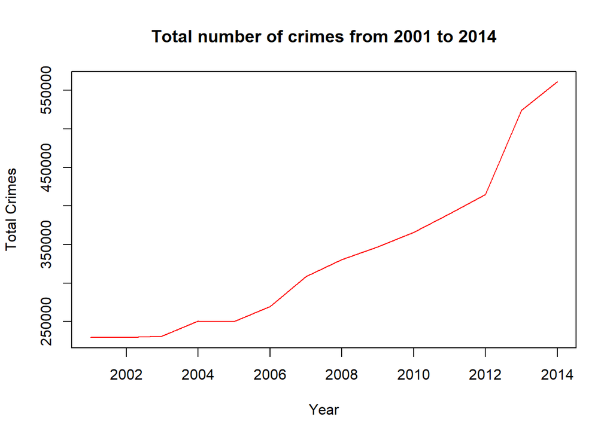

```r
library(ggplot2)
library(dplyr)
library(plotly)
plot(data_aggrT,ylab= "Total Crimes",main="Total number of crimes from 2001 to 2014",type="l", bg="blue",col="red")
```

## b) Analysis by type of crime through the years

Let’s zoom on the different crimes of our dataset.

- Number of Rape for each year

```r
data_aggrR <- aggregate(Rape ~ Year,
                        data,
                        FUN = sum)
head(data_aggrR)
```

```
##   Year  Rape
## 1 2001 32150
## 2 2002 32746
## 3 2003 31694
## 4 2004 36466
## 5 2005 36718
## 6 2006 38696
```

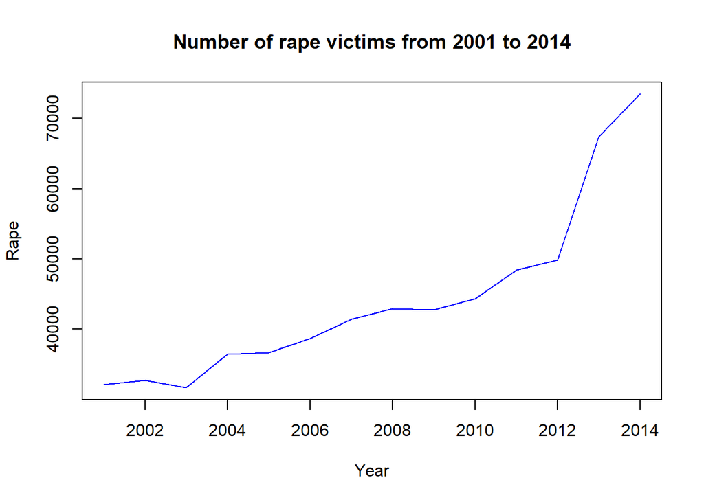

```r
plot(data_aggrR,main="Number of rape victims from 2001 to 2014",type="l", bg="blue",col="blue")
```

First, let’s start with the crime of rape. As we can see on the graph, this crime has been increasing during the period 2001 - 2014 having 32,1K victims in 2001 to 73 470 victims in 2014 (despite a significant decrease in 2003). There is a drastic increase in the number of reported rapes from 2012.

- Number of Kidnapping Abduction for each year

```r
data_aggrK <- aggregate(Kidnapping_Abduction ~ Year,
                        data,
                        FUN = sum)

head(data_aggrK)
```

```
##   Year Kidnapping_Abduction
## 1 2001                29290
## 2 2002                29012
## 3 2003                26592
## 4 2004                31156
## 5 2005                31500
## 6 2006                34828
```

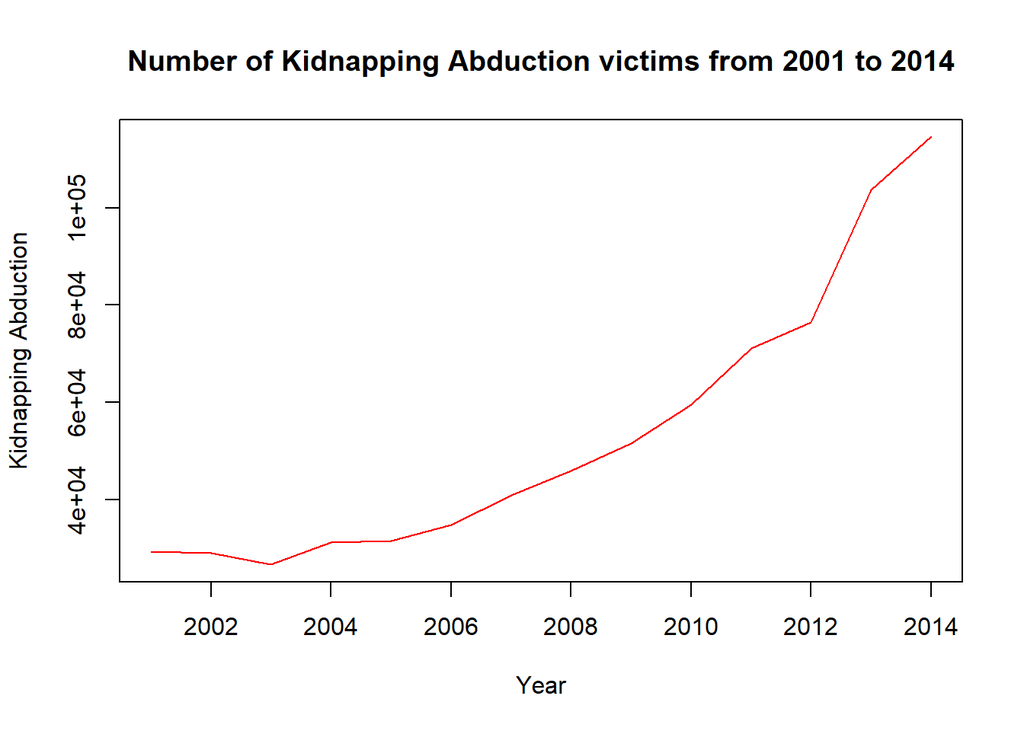

```r
plot(data_aggrK, xlab= "Year", ylab="Kidnapping Abduction",main ="Number of Kidnapping Abduction victims from 2001 to 2014",type="l",col="red")
```

The number of kidnappings and sequestrations recorded also continues to grow. In 2004, we notice that the number of victims becomes more and more important and therefore the curve grows .

- Number of Dowry Deaths for each year

```r
data_aggrD <- aggregate(DowryDeaths  ~ Year,
                              data,
                              FUN = sum)

head(data_aggrD)
```

```
##   Year DowryDeaths
## 1 2001       13702
## 2 2002       13644
## 3 2003       12416
## 4 2004       14052
## 5 2005       13574
## 6 2006       15236
```

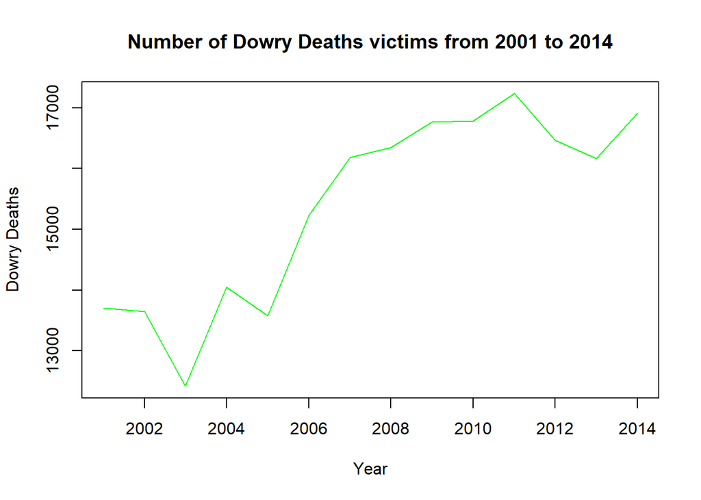

```r
plot(data_aggrD, xlab= "Year", ylab="Dowry Deaths",main ="Number of Dowry Deaths victims from 2001 to 2014",type="l",col="green")
```

After looking at the first two graphs which were quite similar in terms of the shape of their curves, the graph on the number of dowry victims is quite different. Indeed, we notice that between 2002 and 2004 there is an important drop of the number of deaths going up to 12 416 victims in 2003. Then, afterwards, a curve where we can distinguish spikes as in 2004 or in 2011, decreases and increases in the number of victims.

- Assaults&Outrage

```r
data_aggrA <- aggregate(Assaults_Outrage ~ Year,
                        data,
                        FUN = sum)

head(data_aggrA)
```

```
##   Year Assaults_Outrage
## 1 2001            68248
## 2 2002            67886
## 3 2003            65878
## 4 2004            69134
## 5 2005            68350
## 6 2006            73234
```

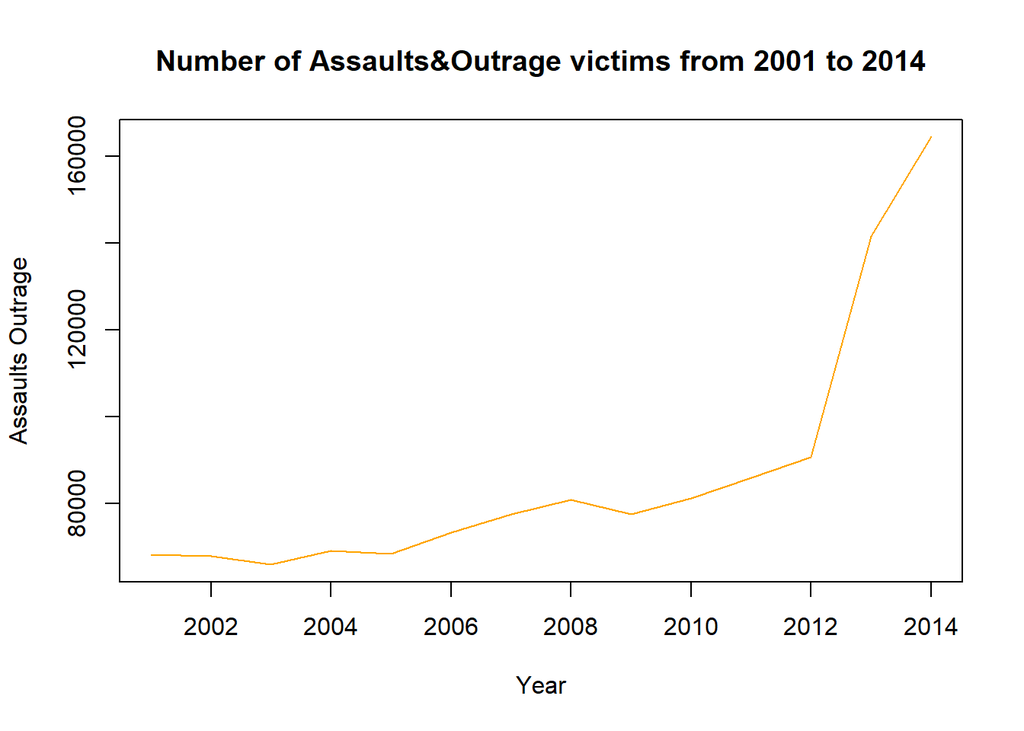

```r
plot(data_aggrA, xlab= "Year", ylab="Assaults Outrage",main ="Number of Assaults&Outrage victims from 2001 to 2014",type="l",col="orange")
```

- Insult

```r
data_aggrI <- aggregate(Insult  ~ Year,
                        data,
                        FUN = sum)

head(data_aggrI)
```

```
##   Year Insult
## 1 2001  19492
## 2 2002  20310
## 3 2003  24650
## 4 2004  20002
## 5 2005  19968
## 6 2006  19932
```

```r
max(data_aggrI)
```

```
## [1] 25178
```

```r
min(data_aggrI)
```

```
## [1] 2001
```

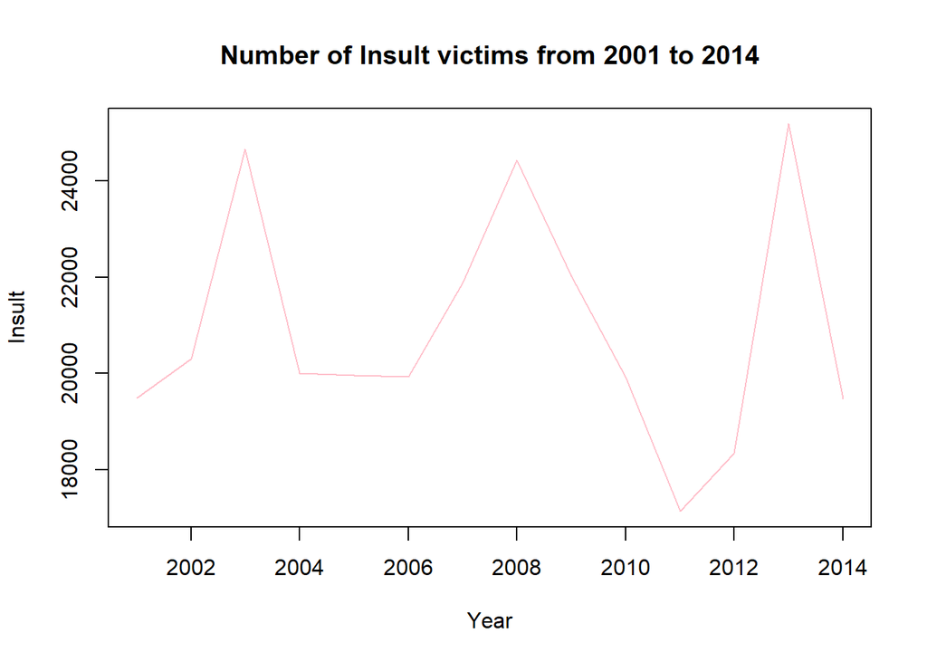

```r
plot(data_aggrI, xlab= "Year", ylab="Insult",main ="Number of Insult victims from 2001 to 2014",type="l",col="pink")
```

- FamilyCruelty

```r
data_aggrF <- aggregate(FamilyCruelty ~ Year,
                        data,
                        FUN = sum)

head(data_aggrF)
```

```
##   Year FamilyCruelty
## 1 2001         98340
## 2 2002         98474
## 3 2003        101406
## 4 2004        116242
## 5 2005        116638
## 6 2006        126256
```

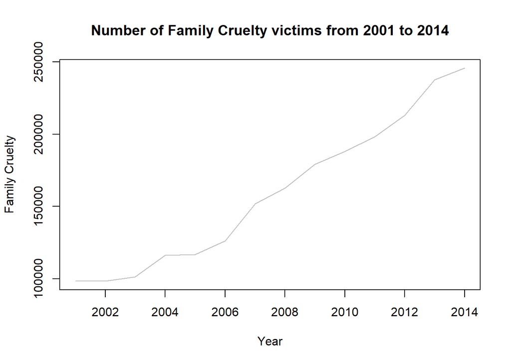

```r
plot(data_aggrF, xlab= "Year", ylab="Family Cruelty",main ="Number of Family Cruelty victims from 2001 to 2014",type="l",col="grey")
```

This last graph shows the evolution of the number of women victims of family cruelty, a curve in continuous increase. It has not stopped growing during the period studied in this project

- Overview of all the crimes

```r
sumcrimes <- aggregate(data[-(1:3)], by=list(data$Year), FUN= sum) %>%
  pivot_longer(!Group.1, names_to = "Crime_type")
head(sumcrimes)
```

```
## # A tibble: 6 x 3
##   Group.1 Crime_type           value
##     <int> <chr>                <int>
## 1    2001 Rape                 32150
## 2    2001 Kidnapping_Abduction 29290
## 3    2001 DowryDeaths          13702
## 4    2001 Assaults_Outrage     68248
## 5    2001 Insult               19492
## 6    2001 FamilyCruelty        98340
```

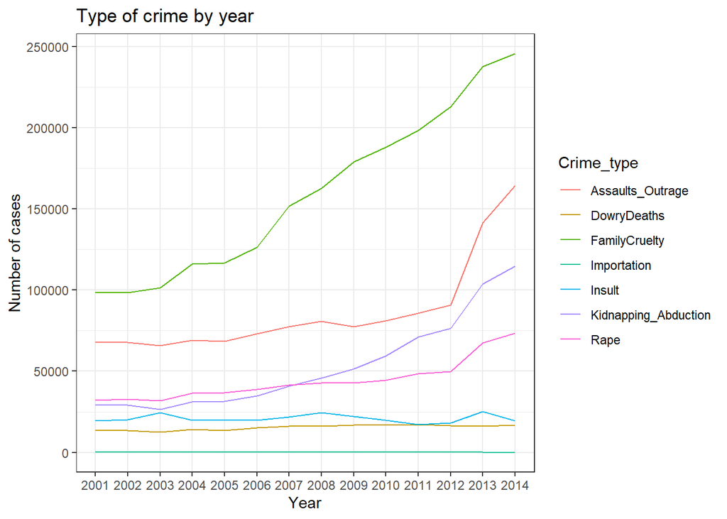

```r
ggplot(sumcrimes, aes(x=Group.1, y=value, color=Crime_type, font.axis=1)) +
  geom_line() +
  labs(title="Type of crime by year",x="Year", y="Number of cases") +
  scale_x_discrete(limits = c(seq(2001,2014,1)))+
  theme(axis.text.x = element_text(angle=45)) +
  theme_bw()
```

## c) Number of distinct states

```r
unique(data$State)
```

```
##  [1] "andhra pradesh"    "arunachal pradesh" "assam"
##  [4] "bihar"             "chhattisgarh"      "goa"
##  [7] "gujarat"           "haryana"           "himachal pradesh"
## [10] "jammu & kashmir"   "jharkhand"         "karnataka"
## [13] "kerala"            "madhya pradesh"    "maharashtra"
## [16] "manipur"           "meghalaya"         "mizoram"
## [19] "nagaland"          "odisha"            "punjab"
## [22] "rajasthan"         "sikkim"            "tamil nadu"
## [25] "tripura"           "uttar pradesh"     "uttarakhand"
## [28] "west bengal"       "a&n islands"       "chandigarh"
## [31] "d&n haveli"        "daman & diu"       "delhi"
## [34] "lakshadweep"       "puducherry"        "telangana"
```

In this database, 36 distinct states are recorded (after taking care of the duplicates), as shown below.

## d) The 5 states with the most criminality

```r
bystate <- aggregate(Total_Crimes ~ State, data_total, FUN = sum)
bystatemax <-  head(bystate[order(bystate$Total_Crimes , decreasing = TRUE), ], 5)
bystatemax
```

```
##             State Total_Crimes
## 2  andhra pradesh       543204
## 34  uttar pradesh       531248
## 36    west bengal       490100
## 29      rajasthan       424502
## 21    maharashtra       380610
```

## e) The 5 states with the least criminality

```r
bystatemin <-  head(bystate[order(bystate$Total_Crimes), ], 5)
bystatemin
```

```
##          State Total_Crimes
## 19 lakshadweep           34
## 9  daman & diu          170
## 8   d&n haveli          434
## 25    nagaland          510
## 30      sikkim          912
```

# 3. Hypothesis testing (Ilona & Salomé)

```r
aggstate <- aggregate(data[-(1:3)], by=list(data$State), FUN=sum)
head(aggstate)
```

```
##             Group.1  Rape Kidnapping_Abduction DowryDeaths Assaults_Outrage
## 1       a&n islands   336                  212          20              600
## 2    andhra pradesh 32150                34504       13844           126952
## 3 arunachal pradesh  1316                 1470           6             1996
## 4             assam 40190                62074        3268            38256
## 5             bihar 30758                57086       32206            16958
## 6        chandigarh   770                 1682          90             1088
##   Insult FamilyCruelty Importation
## 1    112           288           0
## 2  86964        280906          34
## 3     48           476           0
## 4    254        115300          22
## 5    694         69770         904
## 6    342          2080           0
```

## a) Hypothesis n°1

The poorest states are the one facing the more family cruelty

```r
poor <- c("bihar", "jharkhand","uttar pradesh")
t.test(data$FamilyCruelty[data$State== "bihar"], data$FamilyCruelty[data$State== "jharkhand"])
```

```
##
##  Welch Two Sample t-test
##
## data:  data$FamilyCruelty[data$State == "bihar"] and data$FamilyCruelty[data$State == "jharkhand"]
## t = 2.445, df = 957.54, p-value = 0.01467
## alternative hypothesis: true difference in means is not equal to 0
## 95 percent confidence interval:
##   8.894234 81.241167
## sample estimates:
## mean of x mean of y
## 110.39557  65.32787
```

## b) Hypothesis n°2

North-Eastern states face less dowry deaths than other states

```r
northern <- c("arunachal pradesh","assam","manipur", "meghalaya", "mizoram","nagaland","tripura")
'%!in%' <- Negate('%in%')
t.test(data$DowryDeaths[data$State%in%northern], data$DowryDeaths[data$State%!in%northern])
```

```
##
##  Welch Two Sample t-test
##
## data:  data$DowryDeaths[data$State %in% northern] and data$DowryDeaths[data$State %!in% northern]
## t = -17.008, df = 10649, p-value < 2.2e-16
## alternative hypothesis: true difference in means is not equal to 0
## 95 percent confidence interval:
##  -21.66073 -17.18377
## sample estimates:
## mean of x mean of y
##  3.129701 22.551952
```

# 4. Regression Analysis (Gabriel)

After some introductory analysis of our data set we can now analyse the relationships between our variables, and later on, predict what values these might take in the future. For this, we started by checking which are the correlations between some of the variables, and establish linear regressions in order to see how changes in some of them impact the values of others. We established relationships between the number of Rapes and two other Variables, Insults and Kidnapping Abductions. With these, our goal is to observe if, and how much Insults and Kidnapping Abductions contribute to the increase of Rapes in India. The other relationships we established were between Dowry Deaths and two other variables, Family Cruelty and Assaults Outrage. It might be obvious that an increase in Assaults Outrage and Family Cruelty will result in a higher number of Dowry Deaths, but our goal will be to confirm this and check at which extent it might happen. Finally our regressions were made considering the two regions with higher criminality rates, Uttar Pradesh and Andhra Pradesh.

```r
data_nr <- data1 %>%
  filter(!(District %in% 'TOTAL'))
```

In Uttar Pradesh, the correlation between rapes and insults is extremely close to zero, which indicates that Insults towards women are not related with the number of Rapes. The same occurs with insults and kidnapping abductions. These shows us that the number of insults probably do not affect the number of rapes and kidnapping abductions. On the other hand, the relationship between kidnapping abductions and rapes is extremely positive. This means that, if both occur, they will vary perfectly in the same direction.

```r
y_rape_uttar <- data_nr[data_nr$State=='uttar pradesh',]$Rape
x1_uttar <- data_nr[data_nr$State=='uttar pradesh',]$Insult
x2_uttar <- data_nr[data_nr$State=='uttar pradesh',]$Kidnapping_Abduction

cor(cbind(y_rape_uttar,x1_uttar,x2_uttar))
```

```
##              y_rape_uttar    x1_uttar    x2_uttar
## y_rape_uttar   1.00000000 0.017638621 0.995569336
## x1_uttar       0.01763862 1.000000000 0.007652809
## x2_uttar       0.99556934 0.007652809 1.000000000
```

```r
lm(y_rape_uttar~x1_uttar)
```

```
##
## Call:
## lm(formula = y_rape_uttar ~ x1_uttar)
##
## Coefficients:
## (Intercept)     x1_uttar
##    30.00303      0.05593
```

```r
summary(lm(y_rape_uttar~x1_uttar))
```

```
##
## Call:
## lm(formula = y_rape_uttar ~ x1_uttar)
##
## Residuals:
##    Min     1Q Median     3Q    Max
##  -40.2  -20.2  -11.0    3.0 3435.4
##
## Coefficients:
##             Estimate Std. Error t value Pr(>|t|)
## (Intercept) 30.00303    5.22336   5.744 1.22e-08 ***
## x1_uttar     0.05593    0.09937   0.563    0.574
## ---
## Signif. codes:  0 '***' 0.001 '**' 0.01 '*' 0.05 '.' 0.1 ' ' 1
##
## Residual standard error: 144.8 on 1018 degrees of freedom
## Multiple R-squared:  0.0003111,  Adjusted R-squared:  -0.0006709
## F-statistic: 0.3168 on 1 and 1018 DF,  p-value: 0.5736
```

```r
lm(y_rape_uttar~x2_uttar)
```

```
##
## Call:
## lm(formula = y_rape_uttar ~ x2_uttar)
##
## Coefficients:
## (Intercept)     x2_uttar
##      3.9231       0.3181
```

```r
summary(lm(y_rape_uttar~x2_uttar))
```

```
##
## Call:
## lm(formula = y_rape_uttar ~ x2_uttar)
##
## Residuals:
##     Min      1Q  Median      3Q     Max
## -57.285  -5.658  -0.466   6.773  83.290
##
## Coefficients:
##              Estimate Std. Error t value Pr(>|t|)
## (Intercept) 3.9230782  0.4341322   9.037   <2e-16 ***
## x2_uttar    0.3180676  0.0009415 337.814   <2e-16 ***
## ---
## Signif. codes:  0 '***' 0.001 '**' 0.01 '*' 0.05 '.' 0.1 ' ' 1
##
## Residual standard error: 13.62 on 1018 degrees of freedom
## Multiple R-squared:  0.9912, Adjusted R-squared:  0.9911
## F-statistic: 1.141e+05 on 1 and 1018 DF,  p-value: < 2.2e-16
```

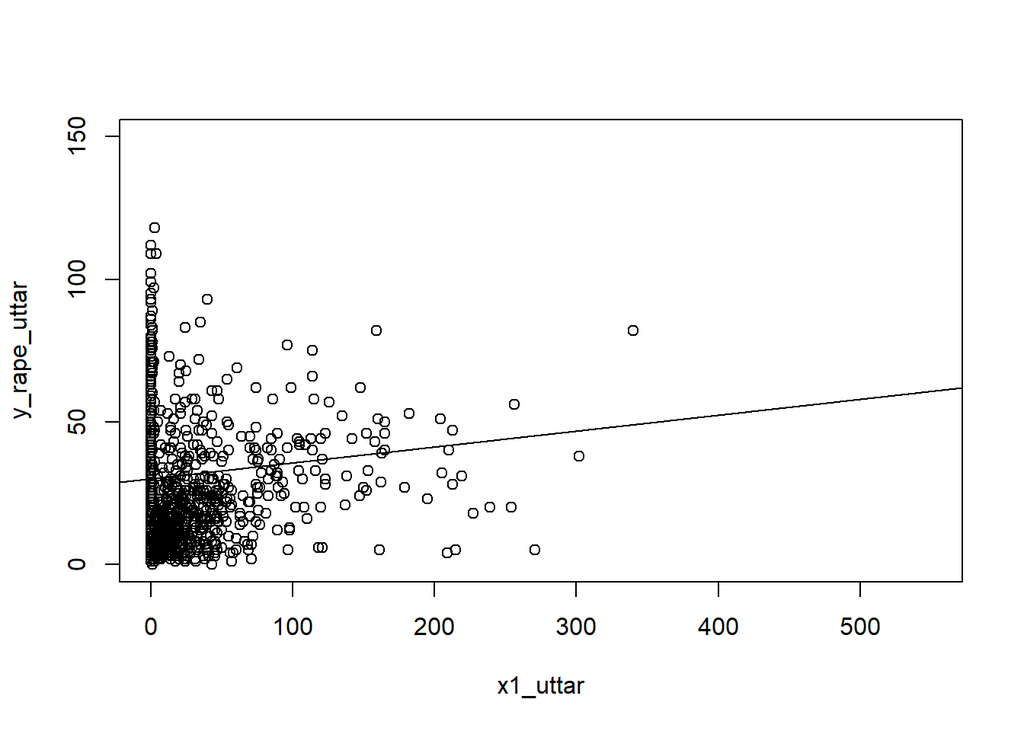

```r
plot(x1_uttar,y_rape_uttar, ylim = c(0,150), xlim = c(0,550))
abline(lm(y_rape_uttar~x1_uttar), pch=16)
```

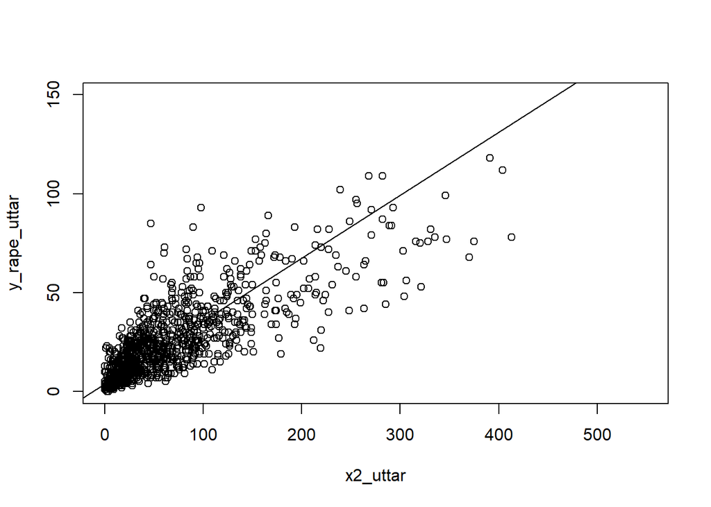

```r
plot(x2_uttar,y_rape_uttar, ylim = c(0,150), xlim = c(0,550))
abline(lm(y_rape_uttar~x2_uttar),pch=16)
```

```r
y_rape_andhra <- data_nr[data_nr$State=='andhra pradesh',]$Rape
x1_andhra <- data_nr[data_nr$State=='andhra pradesh',]$Insult
x2_andhra <- data_nr[data_nr$State=='andhra pradesh',]$Kidnapping_Abduction

cor(cbind(y_rape_andhra,x1_andhra,x2_andhra))
```

```
##               y_rape_andhra x1_andhra x2_andhra
## y_rape_andhra     1.0000000 0.9241689 0.9614848
## x1_andhra         0.9241689 1.0000000 0.9164759
## x2_andhra         0.9614848 0.9164759 1.0000000
```

The linear regressions between these variables, in this region, show us that if both the number of insults and kidnapping abductions change the number of rapes will change in the same direction by a reasonable amount. The relationship between kidnapping abductions and rapes is impressive, since if the number of kidnaps increases by 1 unit, the number of rapes will also increase approximately by 1 unit. Considering that instead of performing single relationships between both variables and the number of rapes we establish a multi-variable relationship, it is curious to observe that the coefficient of Insults in this regression becomes insignificant. This shows us that although insults are a significant variable to take in account when analyzing the number of rapes, kidnapping abductions is much more important, as it is their correlation.

```r
lm(y_rape_andhra~x1_andhra)
```

```
##
## Call:
## lm(formula = y_rape_andhra ~ x1_andhra)
##
## Coefficients:
## (Intercept)    x1_andhra
##      7.2245       0.3086
```

```r
summary(lm(y_rape_andhra~x1_andhra))
```

```
##
## Call:
## lm(formula = y_rape_andhra ~ x1_andhra)
##
## Residuals:
##      Min       1Q   Median       3Q      Max
## -300.140   -9.076   -0.171   15.111  176.718
##
## Coefficients:
##             Estimate Std. Error t value Pr(>|t|)
## (Intercept) 7.224486   1.940486   3.723 0.000224 ***
## x1_andhra   0.308604   0.006292  49.049  < 2e-16 ***
## ---
## Signif. codes:  0 '***' 0.001 '**' 0.01 '*' 0.05 '.' 0.1 ' ' 1
##
## Residual standard error: 36.16 on 411 degrees of freedom
## Multiple R-squared:  0.8541, Adjusted R-squared:  0.8537
## F-statistic:  2406 on 1 and 411 DF,  p-value: < 2.2e-16
```

```r
lm(y_rape_andhra~x2_andhra)
```

```
##
## Call:
## lm(formula = y_rape_andhra ~ x2_andhra)
##
## Coefficients:
## (Intercept)    x2_andhra
##      -3.455        1.027
```

```r
summary(lm(y_rape_andhra~x2_andhra))
```

```
##
## Call:
## lm(formula = y_rape_andhra ~ x2_andhra)
##
## Residuals:
##     Min      1Q  Median      3Q     Max
## -70.416 -13.818   2.855  12.342 223.923
##
## Coefficients:
##             Estimate Std. Error t value Pr(>|t|)
## (Intercept) -3.45548    1.45257  -2.379   0.0178 *
## x2_andhra    1.02709    0.01448  70.918   <2e-16 ***
## ---
## Signif. codes:  0 '***' 0.001 '**' 0.01 '*' 0.05 '.' 0.1 ' ' 1
##
## Residual standard error: 26.02 on 411 degrees of freedom
## Multiple R-squared:  0.9245, Adjusted R-squared:  0.9243
## F-statistic:  5029 on 1 and 411 DF,  p-value: < 2.2e-16
```

```r
lm(y_rape_andhra~x1_andhra+x2_andhra)
```

```
##
## Call:
## lm(formula = y_rape_andhra ~ x1_andhra + x2_andhra)
##
## Coefficients:
## (Intercept)    x1_andhra    x2_andhra
##    -2.03600      0.08968      0.76415
```

```r
summary(lm(y_rape_andhra~x1_andhra+x2_andhra))
```

```
##
## Call:
## lm(formula = y_rape_andhra ~ x1_andhra + x2_andhra)
##
## Residuals:
##     Min      1Q  Median      3Q     Max
## -70.716 -12.590   1.823  10.989 174.508
##
## Coefficients:
##             Estimate Std. Error t value Pr(>|t|)
## (Intercept) -2.03600    1.34874   -1.51    0.132
## x1_andhra    0.08968    0.01043    8.60   <2e-16 ***
## x2_andhra    0.76415    0.03336   22.91   <2e-16 ***
## ---
## Signif. codes:  0 '***' 0.001 '**' 0.01 '*' 0.05 '.' 0.1 ' ' 1
##
## Residual standard error: 23.98 on 410 degrees of freedom
## Multiple R-squared:  0.936,  Adjusted R-squared:  0.9357
## F-statistic:  2998 on 2 and 410 DF,  p-value: < 2.2e-16
```

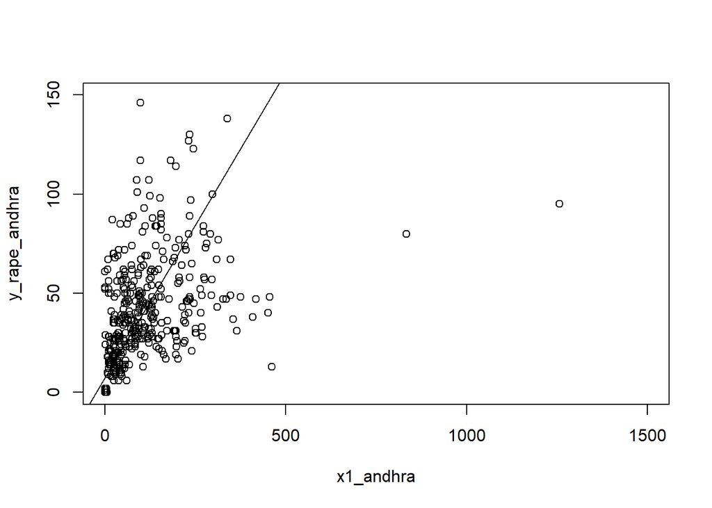

```r
plot(x1_andhra,y_rape_andhra, ylim = c(0,150), xlim = c(0,1500))
abline(lm(y_rape_andhra~x1_andhra), pch=16)
```

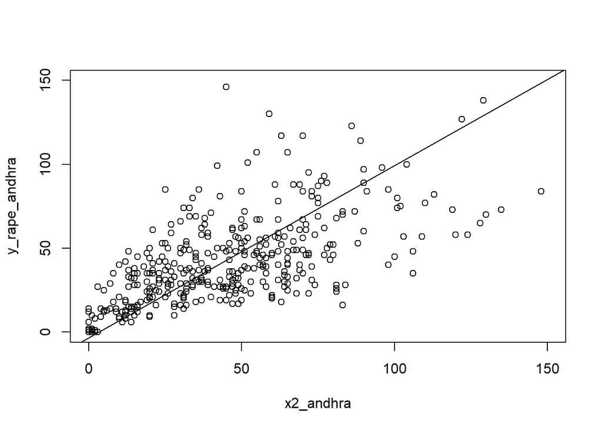

```r
plot(x2_andhra,y_rape_andhra, ylim = c(0,150), xlim = c(0,150))
abline(lm(y_rape_andhra~x2_andhra),pch=16)
```

## a) Correlation for Uttar Deaths

```r
y_Dowry_uttar <- data_nr[data_nr$State=='uttar pradesh',]$DowryDeaths
x3_uttar <- data_nr[data_nr$State=='uttar pradesh',]$FamilyCruelty
x4_uttar <- data_nr[data_nr$State=='uttar pradesh',]$Assaults_Outrage

cor(cbind(y_Dowry_uttar,x3_uttar,x4_uttar))
```

```
##               y_Dowry_uttar  x3_uttar  x4_uttar
## y_Dowry_uttar     1.0000000 0.9753303 0.9890704
## x3_uttar          0.9753303 1.0000000 0.9806623
## x4_uttar          0.9890704 0.9806623 1.0000000
```

For the relationship with other variables we can see that there is a high correlation between the family cruelty and dowry deaths and also with assaults and dowry deaths, in the region of uttar pradesh.

## b) Regression for Uttar Deaths

```r
lm(y_Dowry_uttar~x3_uttar)
```

```
##
## Call:
## lm(formula = y_Dowry_uttar ~ x3_uttar)
##
## Coefficients:
## (Intercept)     x3_uttar
##      5.8246       0.2367
```

```r
summary(lm(y_Dowry_uttar~x3_uttar))
```

```
##
## Call:
## lm(formula = y_Dowry_uttar ~ x3_uttar)
##
## Residuals:
##      Min       1Q   Median       3Q      Max
## -210.218   -5.892    1.992   10.518  250.328
##
## Coefficients:
##             Estimate Std. Error t value Pr(>|t|)
## (Intercept) 5.824579   0.760882   7.655 4.48e-14 ***
## x3_uttar    0.236744   0.001679 140.969  < 2e-16 ***
## ---
## Signif. codes:  0 '***' 0.001 '**' 0.01 '*' 0.05 '.' 0.1 ' ' 1
##
## Residual standard error: 23.52 on 1018 degrees of freedom
## Multiple R-squared:  0.9513, Adjusted R-squared:  0.9512
## F-statistic: 1.987e+04 on 1 and 1018 DF,  p-value: < 2.2e-16
```

```r
lm(y_Dowry_uttar~x4_uttar)
```

```
##
## Call:
## lm(formula = y_Dowry_uttar ~ x4_uttar)
##
## Coefficients:
## (Intercept)     x4_uttar
##     14.8538       0.2972
```

```r
summary(lm(y_Dowry_uttar~x4_uttar))
```

```
##
## Call:
## lm(formula = y_Dowry_uttar ~ x4_uttar)
##
## Residuals:
##      Min       1Q   Median       3Q      Max
## -103.146   -8.129   -1.848    7.897  149.791
##
## Coefficients:
##              Estimate Std. Error t value Pr(>|t|)
## (Intercept) 14.853776   0.498981   29.77   <2e-16 ***
## x4_uttar     0.297187   0.001389  214.03   <2e-16 ***
## ---
## Signif. codes:  0 '***' 0.001 '**' 0.01 '*' 0.05 '.' 0.1 ' ' 1
##
## Residual standard error: 15.71 on 1018 degrees of freedom
## Multiple R-squared:  0.9783, Adjusted R-squared:  0.9782
## F-statistic: 4.581e+04 on 1 and 1018 DF,  p-value: < 2.2e-16
```

```r
lm(y_Dowry_uttar~x3_uttar+x4_uttar)
```

```
##
## Call:
## lm(formula = y_Dowry_uttar ~ x3_uttar + x4_uttar)
##
## Coefficients:
## (Intercept)     x3_uttar     x4_uttar
##    13.46672      0.03414      0.25575
```

```r
summary(lm(y_Dowry_uttar~x3_uttar+x4_uttar))
```

```
##
## Call:
## lm(formula = y_Dowry_uttar ~ x3_uttar + x4_uttar)
##
## Residuals:
##      Min       1Q   Median       3Q      Max
## -102.616   -7.547   -1.557    7.702  154.058
##
## Coefficients:
##              Estimate Std. Error t value Pr(>|t|)
## (Intercept) 13.466718   0.541245  24.881  < 2e-16 ***
## x3_uttar     0.034135   0.005634   6.059 1.92e-09 ***
## x4_uttar     0.255749   0.006974  36.674  < 2e-16 ***
## ---
## Signif. codes:  0 '***' 0.001 '**' 0.01 '*' 0.05 '.' 0.1 ' ' 1
##
## Residual standard error: 15.44 on 1017 degrees of freedom
## Multiple R-squared:  0.979,  Adjusted R-squared:  0.979
## F-statistic: 2.373e+04 on 2 and 1017 DF,  p-value: < 2.2e-16
```

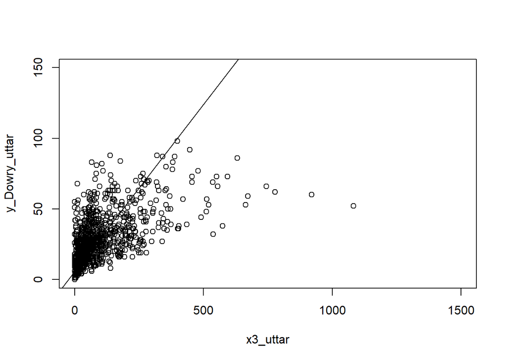

```r
plot(x3_uttar,y_Dowry_uttar, ylim = c(0,150), xlim = c(0,1500))
abline(lm(y_Dowry_uttar~x3_uttar), pch=16)
```

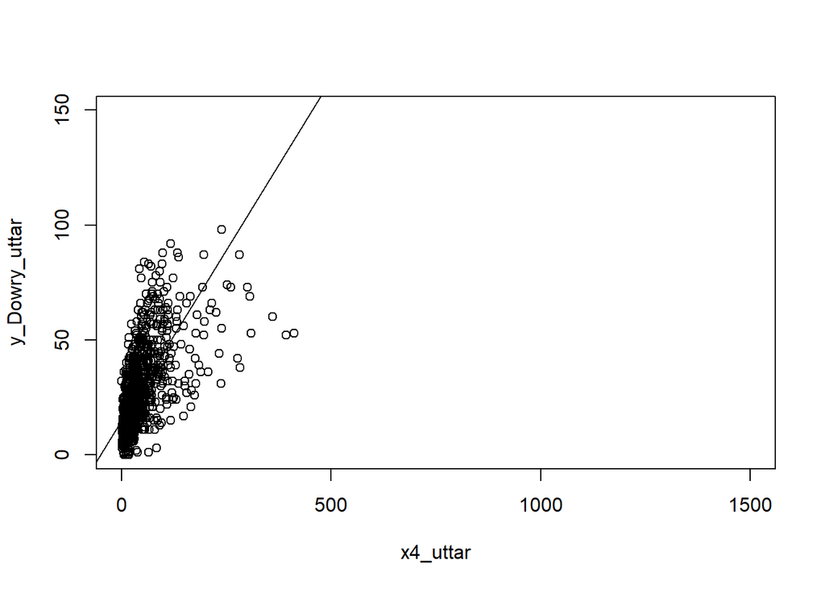

```r
plot(x4_uttar,y_Dowry_uttar, ylim = c(0,150), xlim = c(0,1500))
abline(lm(y_Dowry_uttar~x4_uttar),pch=16)
```

## c) Correlation for Andhra Deaths

```r
y_Dowry_andhra <- data_nr[data_nr$State=='andhra pradesh',]$DowryDeaths

x3_andhra <- data_nr[data_nr$State=='andhra pradesh',]$FamilyCruelty
x4_andhra <- data_nr[data_nr$State=='andhra pradesh',]$Assaults_Outrage

cor(cbind(y_Dowry_andhra,x3_andhra,x4_andhra))
```

```
##                y_Dowry_andhra x3_andhra x4_andhra
## y_Dowry_andhra      1.0000000 0.9148475 0.8981002
## x3_andhra           0.9148475 1.0000000 0.9317593
## x4_andhra           0.8981002 0.9317593 1.0000000
```

In the location of andhra pradesh, it is also possible to observe a high level of correlation between all three variables. On the other hand, it is reasonable to notice that the relationship between assaults and deaths is weaker in comparison to the relationship between family cruelty and deaths.

## d) Regression for Andhra Deaths

```r
lm(y_Dowry_andhra~x3_andhra)
```

```
##
## Call:
## lm(formula = y_Dowry_andhra ~ x3_andhra)
##
## Coefficients:
## (Intercept)    x3_andhra
##     6.17625      0.03137
```

```r
summary(lm(y_Dowry_andhra~x3_andhra))
```

```
##
## Call:
## lm(formula = y_Dowry_andhra ~ x3_andhra)
##
## Residuals:
##     Min      1Q  Median      3Q     Max
## -37.067  -6.270  -3.137   5.659  48.798
##
## Coefficients:
##              Estimate Std. Error t value Pr(>|t|)
## (Intercept) 6.1762473  0.6287323   9.823   <2e-16 ***
## x3_andhra   0.0313665  0.0006829  45.931   <2e-16 ***
## ---
## Signif. codes:  0 '***' 0.001 '**' 0.01 '*' 0.05 '.' 0.1 ' ' 1
##
## Residual standard error: 11.56 on 411 degrees of freedom
## Multiple R-squared:  0.8369, Adjusted R-squared:  0.8365
## F-statistic:  2110 on 1 and 411 DF,  p-value: < 2.2e-16
```

```r
lm(y_Dowry_andhra~x4_andhra)
```

```
##
## Call:
## lm(formula = y_Dowry_andhra ~ x4_andhra)
##
## Coefficients:
## (Intercept)    x4_andhra
##     7.10234      0.06265
```

```r
summary(lm(y_Dowry_andhra~x4_andhra))
```

```
##
## Call:
## lm(formula = y_Dowry_andhra ~ x4_andhra)
##
## Residuals:
##     Min      1Q  Median      3Q     Max
## -76.968  -7.444  -3.435   6.814  50.740
##
## Coefficients:
##             Estimate Std. Error t value Pr(>|t|)
## (Intercept) 7.102341   0.677736   10.48   <2e-16 ***
## x4_andhra   0.062649   0.001513   41.40   <2e-16 ***
## ---
## Signif. codes:  0 '***' 0.001 '**' 0.01 '*' 0.05 '.' 0.1 ' ' 1
##
## Residual standard error: 12.59 on 411 degrees of freedom
## Multiple R-squared:  0.8066, Adjusted R-squared:  0.8061
## F-statistic:  1714 on 1 and 411 DF,  p-value: < 2.2e-16
```

```r
lm(y_Dowry_andhra~x3_andhra+x4_andhra)
```

```
##
## Call:
## lm(formula = y_Dowry_andhra ~ x3_andhra + x4_andhra)
##
## Coefficients:
## (Intercept)    x3_andhra    x4_andhra
##     6.12890      0.02030      0.02417
```

```r
summary(lm(y_Dowry_andhra~x3_andhra+x4_andhra))
```

```
##
## Call:
## lm(formula = y_Dowry_andhra ~ x3_andhra + x4_andhra)
##
## Residuals:
##     Min      1Q  Median      3Q     Max
## -30.169  -6.342  -3.368   5.257  41.317
##
## Coefficients:
##             Estimate Std. Error t value Pr(>|t|)
## (Intercept) 6.128895   0.598202   10.25  < 2e-16 ***
## x3_andhra   0.020296   0.001789   11.34  < 2e-16 ***
## x4_andhra   0.024174   0.003641    6.64 9.99e-11 ***
## ---
## Signif. codes:  0 '***' 0.001 '**' 0.01 '*' 0.05 '.' 0.1 ' ' 1
##
## Residual standard error: 11 on 410 degrees of freedom
## Multiple R-squared:  0.8528, Adjusted R-squared:  0.8521
## F-statistic:  1187 on 2 and 410 DF,  p-value: < 2.2e-16
```

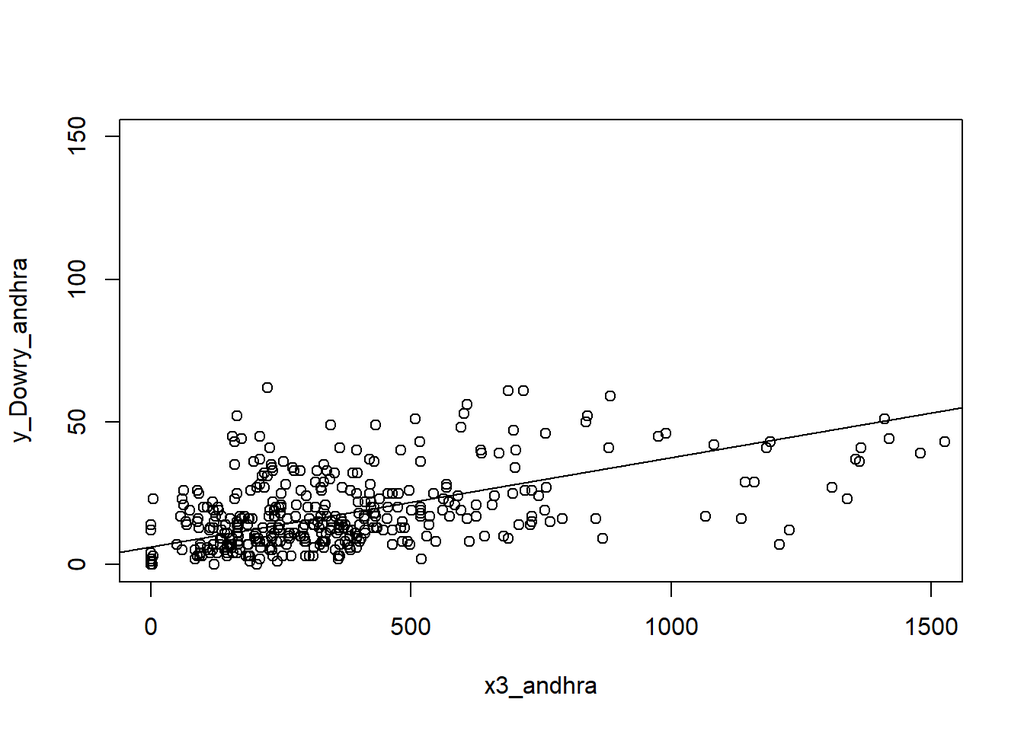

```r
plot(x3_andhra,y_Dowry_andhra, ylim = c(0,150), xlim = c(0,1500))
abline(lm(y_Dowry_andhra~x3_andhra), pch=16)
```

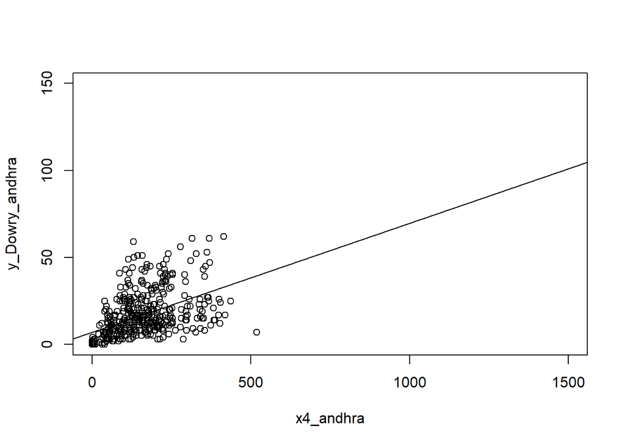

```r
plot(x4_andhra,y_Dowry_andhra, ylim = c(0,150), xlim = c(0,1500))
abline(lm(y_Dowry_andhra~x4_andhra),pch=16)
```

Even though it is confirmed that both independent variables have a high degree of correlation with the number of dowry deaths, in this state, it is possible to observe that the response of number of deaths to the increase on both family cruelty and assaults is very small.

# 5. Forecasting (Cécile & Yingxue)

```r
TotalDowryDeaths <- sum(data_nr$DowryDeaths)
TopIndia <- data_nr %>%
  group_by(State) %>%
  summarize(DowryDeaths = sum(DowryDeaths),) %>%
  top_n(10) %>%
  arrange(desc(DowryDeaths))
```

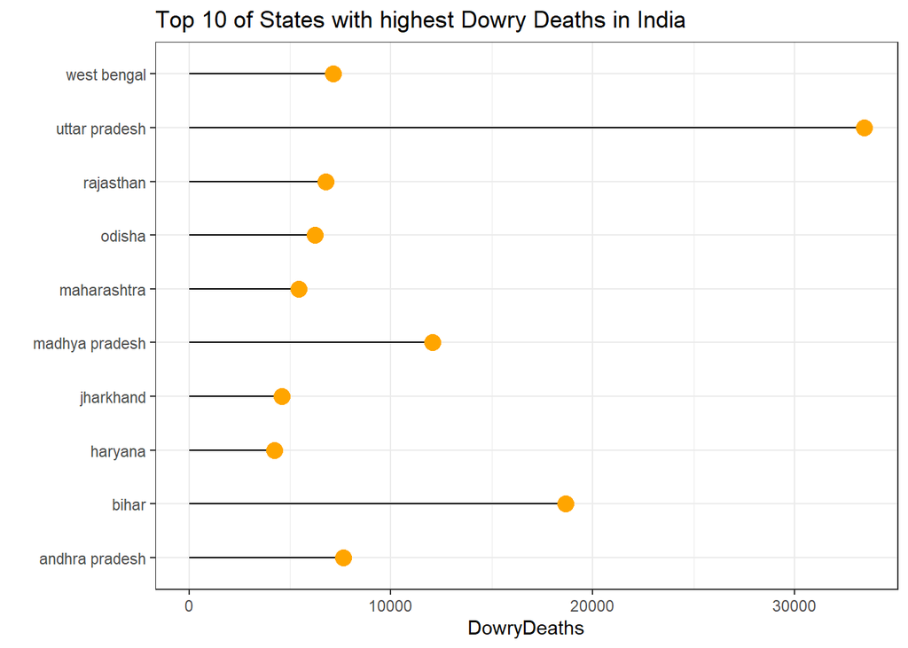

```r
ggplot(TopIndia, aes(x = State, y = DowryDeaths)) +
  geom_segment(aes(xend = State, yend = 0)) +
  geom_point(size = 4, color = "orange") +
  coord_flip() +
  theme_bw() +
  xlab("")+
  ggtitle("Top 10 of States with highest Dowry Deaths in India")
```

To do so, we will conduct different time series forecasting analyses (such as EWMA, ARMA…) based on the data we already have and that have been collected annually between 2001 and 2014. This will help us to answer some questions such as: what is the trend of this kind of crime? What will be situation in the next 12 years? The following parts will help us to understand better this point and to answer our questions.

## a) Plot analysis & trend extraction

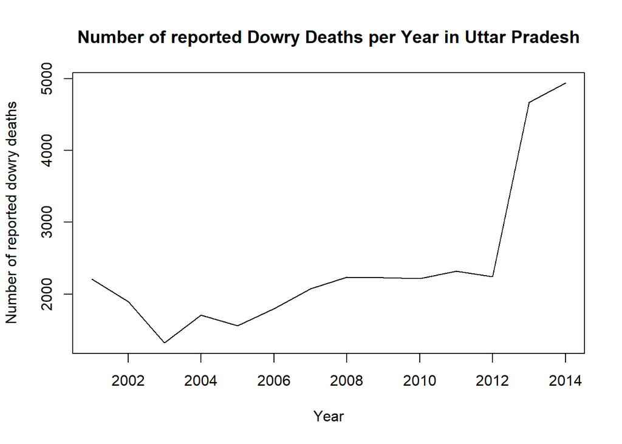

```r
Annual_DD_UP <- data_nr %>%
  filter(State=="uttar pradesh") %>%
  select(c(4,7))%>%
  group_by(Year) %>%
  summarise(DowryDeaths = sum(DowryDeaths))

plot(Annual_DD_UP$Year, Annual_DD_UP$DowryDeaths, type="l", main="Number of reported Dowry Deaths per Year in Uttar Pradesh", xlab="Year", ylab= "Number of reported dowry deaths")
```

## b) Simple Moving Average

- Choosing the k

K has been chosen based on minimizing the sum of squared errors,The chunk below create a Moving average of order 1

```r
y<-rev(Annual_DD_UP$DowryDeaths)
MA<-e<-sumsqe<-c()
# for each k we calculate the sum of squared errors
for(k in 1:12){ # Note that 15 is an arbitrary number.
for(t in (k+1):length(y)){
MA[t]=mean(y[(t-k):(t-1)])
e[t]=y[t]-MA[t]
}
sumsqe[k]<-sum(e[!is.na(e)]^2)
}

k<-which.min(sumsqe)
k
```

```
## [1] 1
```

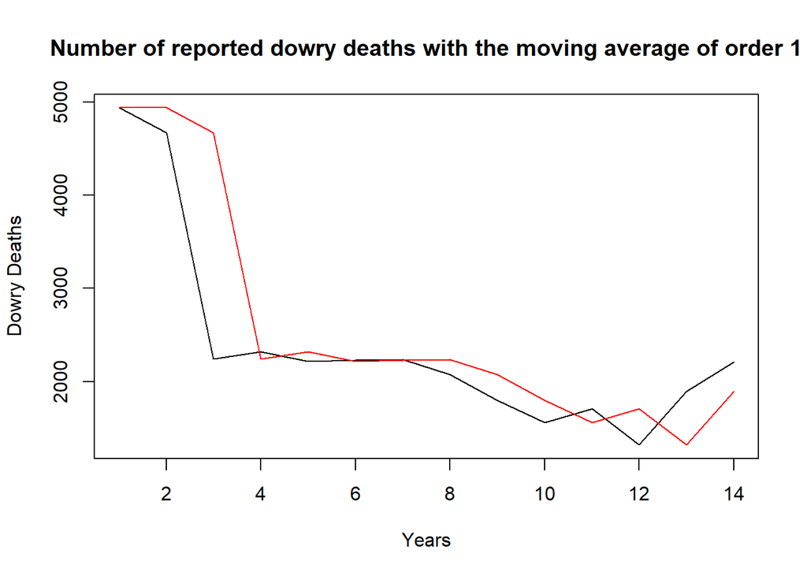

```r
y<-rev(Annual_DD_UP$DowryDeaths)
MA<-c()
k<-1
MA[1:k]=mean(y[1:k])
for(t in (k+1):length(y)){
  MA[t]=mean(y[(t-k):(t-1)])
}
plot(ts(y),main="Number of reported dowry deaths with the moving average of order 1",
     ylab="Dowry Deaths",xlab="Years"); lines(MA,col="red")
```

## c) EWMA

- Choosing alpha

```r
n = length(y)
ALPHA = seq(0, 1, length.out = 100)
sumsqe <- c()
for (i in 1:length(ALPHA)) {
  EWMA <- c()
  EWMA[1] <- y[1]
  alpha = ALPHA[i]
  for (t in 2:n) {
    EWMA[t] = alpha * y[t - 1] + (1 - alpha) * EWMA[t - 1]
  }
  sumsqe[i] = mean((y - EWMA) ^ 2)
}
```

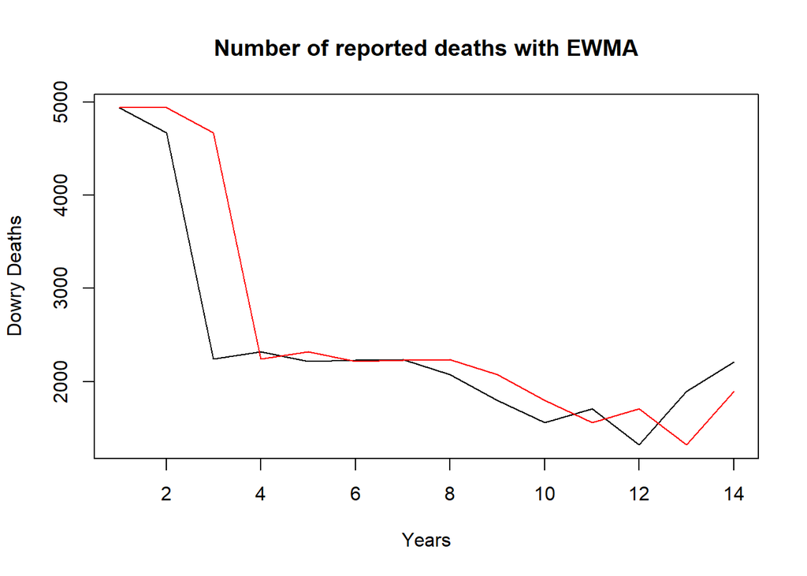

```r
n = length(y)
EWMA <- c()

EWMA[1] <- y[1]
alpha = ALPHA[which.min(sumsqe)]
for (t in 2:n) {
  EWMA[t] = alpha * y[t - 1] + (1 - alpha) * EWMA[t - 1]
}
plot(ts(y),
     main = "Number of reported deaths with EWMA",
     ylab = "Dowry Deaths",
     xlab = "Years"); lines(EWMA, col = "red")
```

## d) ARMA

From our dowry death time series, we will conduct a forecasting analysis using the ARMA model. Despite this model is in principle conceived for stationary data, using it on our time series would still be interesting to understand and predict future values.

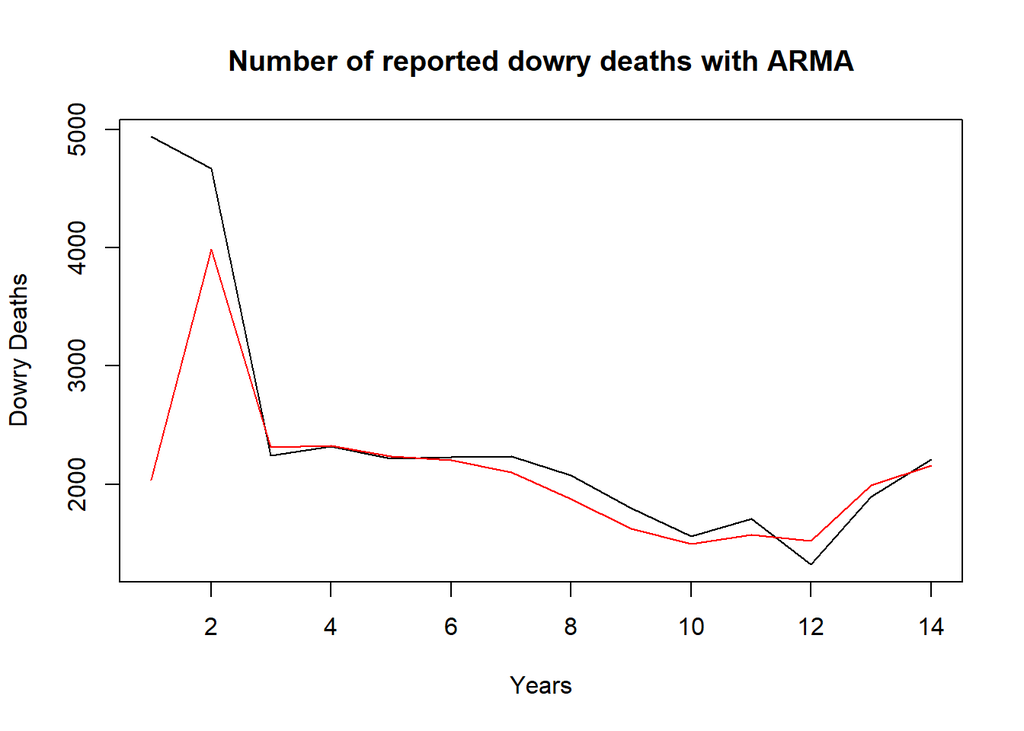

```r
y <- rev(Annual_DD_UP$DowryDeaths)
e <- c()
e[1] = 0
sumsqerr <-
  function(param) {
    phi = param[1]
    theta = param[2]
    const = param[3]

    for (t in 2:length(y)) {
      e[t] <- y[t] - (const + phi * y[t - 1] + theta * e[t - 1])
    }
    mean(e ^ 2)
  }
results <- optim(c(.9, -.7, 400), sumsqerr)
phi = results[[1]][1]
theta = results[[1]][2]
const = results[[1]][3]

yhat = c()
yhat[1] = const / (1 - phi)
for (t in 2:length(y)) {
  yhat[t] <- const + phi * y[t - 1] + theta * e[t - 1]
  e[t] <- y[t] - (const + phi * y[t - 1] + theta * e[t - 1])
}
plot(ts(y),
     main = "Number of reported dowry deaths with ARMA",
     ylab = "Dowry Deaths",
     xlab = "Years")
lines(yhat, col = "red")
```

The parameters of our model are the following ones:

```r
print(c(const,phi,theta))
```

```
## [1] 664.6140754   0.6735693  -2.2055309
```

## e) Pick a technique

Since we used three models to forecast, we want to know which one is the best solution for forecasting,thus we try to rank the forecasting models.

In order to assess which forecast is best, we will use the Root Mean Squared Scale Error (RMSSE).

Let’s define:  
- Insample: the data used for estimating the model,  
- Outsample: the data to be forecasted, - Forc: the forecast provided by a model and h the steps ahead - h: the time horizon to forecast

```r
rmsse <- function(Outsample, Insample, Forc, h) {
  sqrt(mean((Outsample[1:h] - Forc[1:h]) ^ 2) / mean(diff(Insample) ^ 2))
}


OUT <- tail(y, 12)
IN <- head(y, length(y) - 12)


rmsse(OUT, IN, EWMA, 12)
```

```
## [1] 4.995692
```

```r
rmsse(OUT, IN, yhat, 12)
```

```
## [1] 2.063468
```

```r
rmsse(OUT, IN, MA, 12)
```

```
## [1] 4.995692
```

As our RMSSE function applied to our different predictions using the 3 different models are above 1, it means that our forecast errors squared are bigger than the means of our differences data squared.

Therefore, it looks like the Random walk will be the best predictor of the series. This model assumes that the variable takes a random step away from its previous value at each period and the steps are independently and identically distributed in size.

## f) Random walk

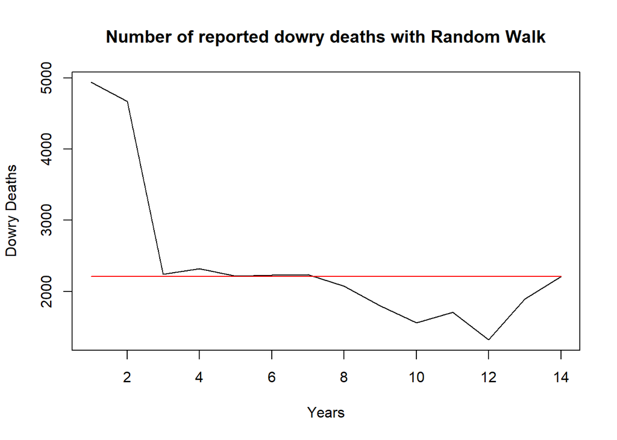

```r
n = length(y)
RW <- c()
RW[1] = y[n]
for (t in 2:n) {
  RW[t] = RW[t - 1]
}

plot(ts(y),
     main = "Number of reported dowry deaths with Random Walk",
     ylab = "Dowry Deaths",
     xlab = "Years");
lines(RW, col = "red")
```

```r
rmsse(OUT, IN, RW, 12)
```

```
## [1] 1.4316
```

The RMSSE obtained applying the Random Walk model is still above 1. However, it is the lowest RMSSE we found so far. Thus, we can conclude that the random walk model can be considered as the best model to use to predict the future reported dowry deaths among ARMA, EWMA and SMA.